# BAX-441 002 Homework -3

Statistical Exploration and Reasoning

Vamsee Krishna Reddy Narahari

2022-11-13

## Question-1

```r
df_electronics <- read.csv("Electronics.csv")
head(df_electronics,2)
```

```
##   Store Households Location  Sales
## 1     1        161   Street 157.27
## 2     2         99   Street  93.28
```

```r
df_electronics$street <- ifelse(df_electronics$Location == "Street", 1,0)
df_electronics$mall <- ifelse(df_electronics$Location == "Mall", 1,0)
df_electronics$downtown <- ifelse(df_electronics$Location == "Downtown", 1,0)
```

```r
electronics_model <- lm(Sales ~ Households + mall + downtown, data =df_electronics)
summary(electronics_model)
```

```
##
## Call:
## lm(formula = Sales ~ Households + mall + downtown, data = df_electronics)
##
## Residuals:
##     Min      1Q  Median      3Q     Max
## -13.834  -2.999   2.225   4.357   6.431
##
## Coefficients:
##             Estimate Std. Error t value Pr(>|t|)
## (Intercept) 14.97769    6.18845   2.420    0.034 *
## Households   0.86859    0.04049  21.452 2.52e-10 ***
## mall        28.37376    4.46131   6.360 5.37e-05 ***
## downtown     6.86378    4.77048   1.439    0.178
## ---
## Signif. codes:  0 '***' 0.001 '**' 0.01 '*' 0.05 '.' 0.1 ' ' 1
##
## Residual standard error: 6.349 on 11 degrees of freedom
## Multiple R-squared:  0.9868, Adjusted R-squared:  0.9833
## F-statistic: 275.1 on 3 and 11 DF,  p-value: 1.268e-10
```

```
## Since the values are in thousands we need to multiply the coefficients with the 1000 to draw the interpretations.
## Holding the location of the store constant, for every 1000 number of households increase, there will be 868 dollars increase in the sales.
## Controlling the household variable, the average sales in the street would be 14978 dollars.
## Controlling the household variable, the average sales in the mall would be 43352 dollars.
## Controlling the household variables, the average sales in the downtown would be 21842 dollars.
## Note:The difference in average sales of street and downtown are not significantly different, holding the household constant
```

```r
confint(electronics_model,level = 0.95)
```

```
##                  2.5 %     97.5 %
## (Intercept)  1.3570167 28.5983697
## Households   0.7794707  0.9577061
## mall        18.5544864 38.1930257
## downtown    -3.6359712 17.3635248
```

[output not shown]

## Question-2

```r
df_winter <- read.csv("WinterFun.csv")
head(df_winter,2)
```

```
##   TIME YEAR QUARTER SALES
## 1    1 2008       1 221.0
## 2    2 2008       2 203.5
```

# 2.a

$y = \beta_{1} + \beta_{2}*time + \epsilon$

```r
sales_t <- lm(SALES ~ TIME, data = df_winter)
summary(sales_t)
```

```
##
## Call:
## lm(formula = SALES ~ TIME, data = df_winter)
##
## Residuals:
##     Min      1Q  Median      3Q     Max
## -33.799 -13.209   2.118  13.724  28.086
##
## Coefficients:
##             Estimate Std. Error t value Pr(>|t|)
## (Intercept)  199.017      5.128   38.81  < 2e-16 ***
## TIME           2.556      0.218   11.73 3.42e-14 ***
## ---
## Signif. codes:  0 '***' 0.001 '**' 0.01 '*' 0.05 '.' 0.1 ' ' 1
##
## Residual standard error: 15.91 on 38 degrees of freedom
## Multiple R-squared:  0.7835, Adjusted R-squared:  0.7778
## F-statistic: 137.5 on 1 and 38 DF,  p-value: 3.417e-14
```

# 2.b

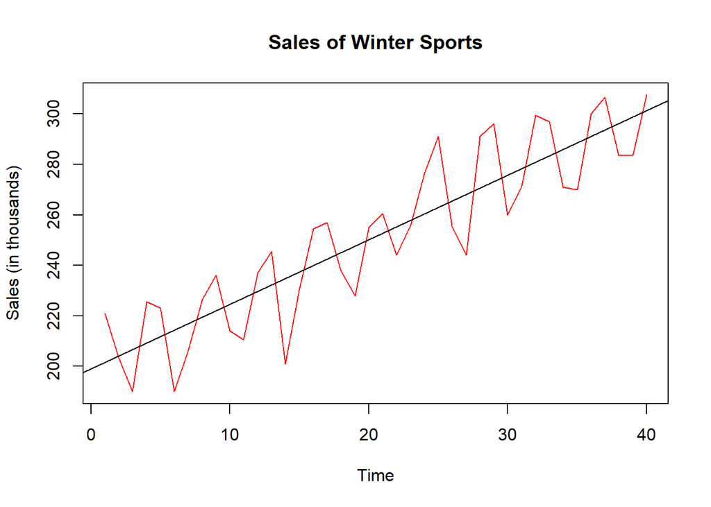

```
## While there is general trend line of sales over time, we can see clear pattern of ups and downs visually. So, we can clearly see that there is seasonality in the given sales data. Seasonality is something we see same patters for certain time over years.
```

```r
plot( df_winter$TIME, df_winter$SALES,
     type = "l",
     xlab = "Time",
     ylab = "Sales (in thousands)",
     main = "Sales of Winter Sports",
     col = "red")
abline(sales_t)
```

#2.c

```r
df_winter$q1 <- ifelse(df_winter$QUARTER == "1", 1, 0)
df_winter$q2  <- ifelse(df_winter$QUARTER == "2", 1, 0)
df_winter$q3  <- ifelse(df_winter$QUARTER == "3", 1, 0)
df_winter$q4  <- ifelse(df_winter$QUARTER == "4", 1, 0)
head(df_winter,5)
```

```
##   TIME YEAR QUARTER SALES q1 q2 q3 q4
## 1    1 2008       1 221.0  1  0  0  0
## 2    2 2008       2 203.5  0  1  0  0
## 3    3 2008       3 190.0  0  0  1  0
## 4    4 2008       4 225.5  0  0  0  1
## 5    5 2009       1 223.0  1  0  0  0
```

#2.d

Reduced model: $y = \beta_{0} + \beta_{1}*time + \epsilon$ Full model: $y = \beta_{0} + \beta_{1}*time + \beta_{2}*Q2 + \beta_{3}*Q3 + \beta_{4}*Q4 + \epsilon$

**Hypothesis:**  
$H_{o}$ : $\beta_{Q2}$ $=$ $\beta_{Q3}$ $=$ $\beta_{Q4}$ $=$ 0  
$H_{1}$ : At least one beta(i) is not equal to zero.

```r
sales_t_full <- lm(SALES ~ TIME + q2 + q3 + q4, data = df_winter)
summary(sales_t_full)
```

```
##
## Call:
## lm(formula = SALES ~ TIME + q2 + q3 + q4, data = df_winter)
##
## Residuals:
##     Min      1Q  Median      3Q     Max
## -19.653  -4.478  -1.429   4.148  13.640
##
## Coefficients:
##              Estimate Std. Error t value Pr(>|t|)
## (Intercept) 214.59413    2.95039  72.734  < 2e-16 ***
## TIME          2.56610    0.09895  25.932  < 2e-16 ***
## q2          -29.86610    3.21712  -9.284 5.72e-11 ***
## q3          -29.53220    3.22168  -9.167 7.85e-11 ***
## q4           -3.74830    3.22927  -1.161    0.254
## ---
## Signif. codes:  0 '***' 0.001 '**' 0.01 '*' 0.05 '.' 0.1 ' ' 1
##
## Residual standard error: 7.19 on 35 degrees of freedom
## Multiple R-squared:  0.9593, Adjusted R-squared:  0.9546
## F-statistic: 206.1 on 4 and 35 DF,  p-value: < 2.2e-16
```

```r
anova(sales_t,sales_t_full)
```

```
## Analysis of Variance Table
##
## Model 1: SALES ~ TIME
## Model 2: SALES ~ TIME + q2 + q3 + q4
##   Res.Df    RSS Df Sum of Sq      F    Pr(>F)
## 1     38 9622.1
## 2     35 1809.5  3    7812.6 50.371 8.723e-13 ***
## ---
## Signif. codes:  0 '***' 0.001 '**' 0.01 '*' 0.05 '.' 0.1 ' ' 1
```

```
## Since the p-value is less than the significance value, we would be rejecting the null hypothesis and conclude that the seasonlity indicator variables are significantly explaining the variation in the sales. And we need to include the seasonality variables in the model
```

```r
anova(sales_t)
```

```
## Analysis of Variance Table
##
## Response: SALES
##           Df Sum Sq Mean Sq F value    Pr(>F)
## TIME       1  34818   34818   137.5 3.417e-14 ***
## Residuals 38   9622     253
## ---
## Signif. codes:  0 '***' 0.001 '**' 0.01 '*' 0.05 '.' 0.1 ' ' 1
```

```r
anova(sales_t_full)
```

```
## Analysis of Variance Table
##
## Response: SALES
##           Df Sum Sq Mean Sq  F value    Pr(>F)
## TIME       1  34818   34818 673.4576 < 2.2e-16 ***
## q2         1   2647    2647  51.1924 2.414e-08 ***
## q3         1   5096    5096  98.5730 1.023e-11 ***
## q4         1     70      70   1.3473    0.2536
## Residuals 35   1810      52
## ---
## Signif. codes:  0 '***' 0.001 '**' 0.01 '*' 0.05 '.' 0.1 ' ' 1
```

```r
partial_r_square <- (9622 - 1810)/9622
```

```
## The partial coefficient of determination is 81.2% suggests that the proportion of the unexplained in the timeseries model is 81.2% explained by the seasonality indicator variables
```

## Question-3

```r
df_empdisc <- read.csv("EmploymentDiscrimination.csv")
head(df_empdisc,2)
```

```
##   SALARY EDUCAT GENDER
## 1   3900     12 FEMALE
## 2   4020     10 FEMALE
```

# 3.a

```r
df_empdisc$male <- ifelse(df_empdisc$GENDER == "MALE", 1, 0)
df_empdisc$female <- ifelse(df_empdisc$GENDER == "FEMALE", 1, 0)
```

$y = \beta_{0} + \beta_{1}*educat + \beta_{2}*male_dummy +\epsilon$

```r
empdisc_3a <- lm(SALARY ~ EDUCAT + male, data=df_empdisc)
summary(empdisc_3a)
```

```
##
## Call:
## lm(formula = SALARY ~ EDUCAT + male, data = df_empdisc)
##
## Residuals:
##      Min       1Q   Median       3Q      Max
## -1241.50  -364.29    16.41   378.50  1943.90
##
## Coefficients:
##             Estimate Std. Error t value Pr(>|t|)
## (Intercept)  4173.13     339.18  12.304  < 2e-16 ***
## EDUCAT         80.70      27.67   2.916  0.00447 **
## male          691.81     132.23   5.232 1.09e-06 ***
## ---
## Signif. codes:  0 '***' 0.001 '**' 0.01 '*' 0.05 '.' 0.1 ' ' 1
##
## Residual standard error: 572.4 on 90 degrees of freedom
## Multiple R-squared:  0.3634, Adjusted R-squared:  0.3492
## F-statistic: 25.68 on 2 and 90 DF,  p-value: 1.498e-09
```

#3.b

```
## Keeping the genders constant, as the education level increases by 1 unit, the salary increases by $81.
## Holding the education level constant, the average salary for the female employees is 4173 dollars and the average salary for the male employees is 4865 dollars.
## As the p-value is very less than the significance value for the male dummy variable, we can conclude that the there is gender descrimination in the department
```

# 3.c

$y = \beta_{0} + \beta_{1}*educat + \beta_{2}*male_dummy + \beta_{3}*male_dummy*educat + \epsilon$

```r
empdisc_3c <- lm(SALARY ~ EDUCAT + male + EDUCAT:male, data=df_empdisc)
summary(empdisc_3c)
```

```
##
## Call:
## lm(formula = SALARY ~ EDUCAT + male + EDUCAT:male, data = df_empdisc)
##
## Residuals:
##      Min       1Q   Median       3Q      Max
## -1240.89  -349.06    72.72   372.72  1808.08
##
## Coefficients:
##             Estimate Std. Error t value Pr(>|t|)
## (Intercept)  4395.32     389.21  11.293   <2e-16 ***
## EDUCAT         62.13      31.94   1.945   0.0549 .
## male         -274.86     845.75  -0.325   0.7460
## EDUCAT:male    73.59      63.59   1.157   0.2503
## ---
## Signif. codes:  0 '***' 0.001 '**' 0.01 '*' 0.05 '.' 0.1 ' ' 1
##
## Residual standard error: 571.4 on 89 degrees of freedom
## Multiple R-squared:  0.3728, Adjusted R-squared:  0.3516
## F-statistic: 17.63 on 3 and 89 DF,  p-value: 4.557e-09
```

```
## Since the p-value is higher than the significance value, we can conclude that the there is no effect of gender on salary depend on the level of education
```

# 3.d

[figure not shown]

```
## The two regression are dissimilar in nature
```

```r
DiscCase_Males <- subset(df_empdisc, df_empdisc$GENDER == "MALE")
DiscCase_Females <- subset(df_empdisc, df_empdisc$GENDER == "FEMALE")

plot(df_empdisc$EDUCAT, df_empdisc$SALARY,
     main = "Education and Salary",
     xlab = "Experience (in years)",
     ylab = "Salary",
     col = ifelse(df_empdisc$GENDER == "Male", "blue", "red"))
legend("topleft",
       pch = c(1, 1),
       c("Female", "Male"),
       col = c("red", "blue"),
       cex = 0.5)

abline(lm(DiscCase_Females$SALARY ~ DiscCase_Females$EDUCAT), col = "red")
abline(lm(DiscCase_Males$SALARY ~ DiscCase_Males$EDUCAT), col = "blue")
```

#3.e

[output not shown]

#3.f

```r
anova(empdisc_3a,empdisc_3c)
```

```
## Analysis of Variance Table
##
## Model 1: SALARY ~ EDUCAT + male
## Model 2: SALARY ~ EDUCAT + male + EDUCAT:male
##   Res.Df      RSS Df Sum of Sq     F Pr(>F)
## 1     90 29491546
## 2     89 29054426  1    437121 1.339 0.2503
```

**Hypothesis:**  
$H_{o}$ : $\beta_{male}$ $=$ $\beta_{male:educat}$ $=$ 0  
$H_{1}$ : At least one beta(i) is not equal to zero.

[output not shown]

```r
anova(model_reduced_3f,empdisc_3c)
```

```
## Analysis of Variance Table
##
## Model 1: SALARY ~ EDUCAT
## Model 2: SALARY ~ EDUCAT + male + EDUCAT:male
##   Res.Df      RSS Df Sum of Sq      F    Pr(>F)
## 1     91 38460756
## 2     89 29054426  2   9406330 14.407 3.799e-06 ***
## ---
## Signif. codes:  0 '***' 0.001 '**' 0.01 '*' 0.05 '.' 0.1 ' ' 1
```

```
## As the p-value is less than the significance value, we can conclude that the atleast one of the gender dummy variable or interaction had significant effect on the salaries of the employees.
```

#3.g

[output not shown]

# Question-4

```r
df_videoconf <- read.csv("Downloads.csv")
colnames(df_videoconf) <- c("time","size","vendor")
head(df_videoconf,2)
```

```
##   time size vendor
## 1 18.4   22     MS
## 2 22.4   22     NP
```

```r
df_videoconf$ms <- ifelse(df_videoconf$vendor == "MS", 1, 0)
df_videoconf$np <- ifelse(df_videoconf$vendor == "NP", 1, 0)
```

```r
model_que4 <- lm(time ~ size + np,data=df_videoconf)
summary(model_que4)
```

```
##
## Call:
## lm(formula = time ~ size + np, data = df_videoconf)
##
## Residuals:
##      Min       1Q   Median       3Q      Max
## -14.5075  -3.7964   0.0604   3.3892  11.9735
##
## Coefficients:
##             Estimate Std. Error t value Pr(>|t|)
## (Intercept)  4.50716    1.66518   2.707  0.00837 **
## size         0.31331    0.02474  12.666  < 2e-16 ***
## np           5.53500    1.25555   4.408 3.33e-05 ***
## ---
## Signif. codes:  0 '***' 0.001 '**' 0.01 '*' 0.05 '.' 0.1 ' ' 1
##
## Residual standard error: 5.615 on 77 degrees of freedom
## Multiple R-squared:  0.7002, Adjusted R-squared:  0.6924
## F-statistic: 89.93 on 2 and 77 DF,  p-value: < 2.2e-16
```

```
## Keeping the vendor constant, as the file size increases by 1 unit, the transfer time would increase by 0.3 seconds. Controlling the file size, the vendor MS system takes an average of 4.5 seconds for file transfer and the vendor np takes average of 5.5 seconds more than vendor ms
```

```r
model_que4_intr <- lm(time ~ size + np + size:np,data=df_videoconf)
summary(model_que4_intr)
```

```
##
## Call:
## lm(formula = time ~ size + np + size:np, data = df_videoconf)
##
## Residuals:
##      Min       1Q   Median       3Q      Max
## -15.2648  -2.7728  -0.0858   3.4596  11.6060
##
## Coefficients:
##             Estimate Std. Error t value Pr(>|t|)
## (Intercept)  9.65635    1.99593   4.838 6.71e-06 ***
## size         0.22289    0.03201   6.963 1.03e-09 ***
## np          -4.76337    2.82268  -1.688 0.095601 .
## size:np      0.18083    0.04527   3.994 0.000149 ***
## ---
## Signif. codes:  0 '***' 0.001 '**' 0.01 '*' 0.05 '.' 0.1 ' ' 1
##
## Residual standard error: 5.138 on 76 degrees of freedom
## Multiple R-squared:  0.7522, Adjusted R-squared:  0.7424
## F-statistic: 76.91 on 3 and 76 DF,  p-value: < 2.2e-16
```

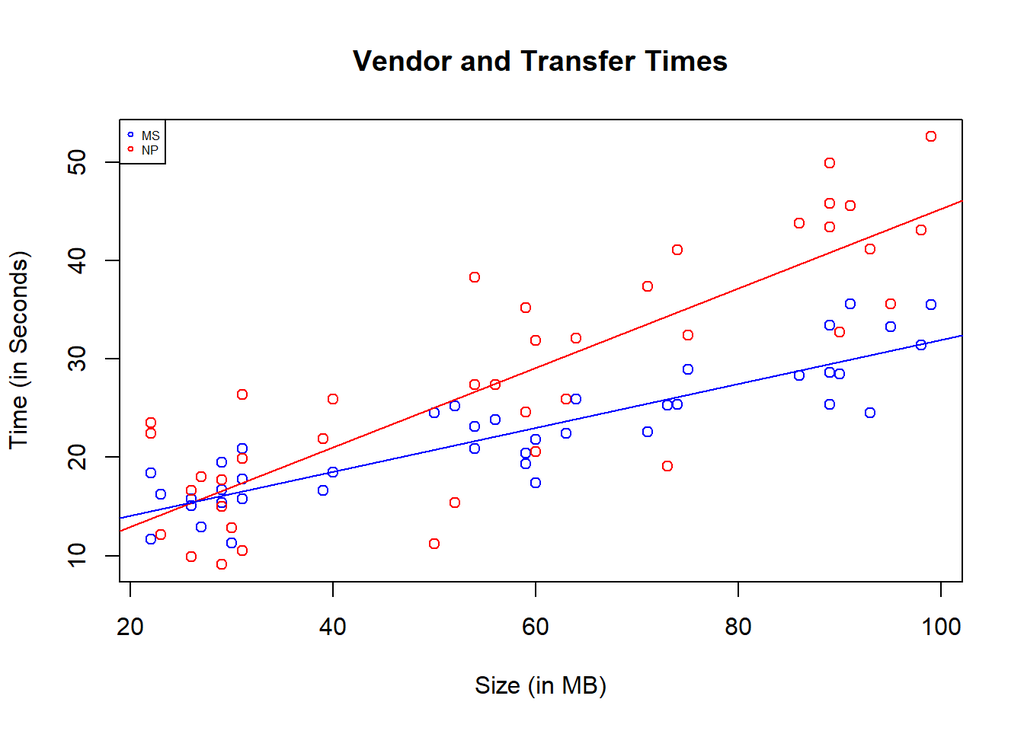

[output not shown]

```r
DiscCase_ms <- subset(df_videoconf, df_videoconf$vendor == "MS")
DiscCase_np <- subset(df_videoconf, df_videoconf$vendor == "NP")

plot(df_videoconf$size, df_videoconf$time,
     main = "Vendor and Transfer Times",
     xlab = "Size (in MB)",
     ylab = "Time (in Seconds)",
     col = ifelse(df_videoconf$vendor == "MS", "blue", "red"))
legend("topleft",
       pch = c(1, 1),
       c("MS", "NP"),
       col = c("blue", "red"),
       cex = 0.5)

abline(lm(DiscCase_np$time ~ DiscCase_np$size), col = "red")
abline(lm(DiscCase_ms$time ~ DiscCase_ms$size), col = "blue")
```

# Question-5

```r
df_fisher <- read.csv("Fisher Index.csv")
head(df_fisher,2)
```

```
##   Year    Y    X
## 1 1971 67.5 19.5
## 2 1972 19.2  8.5
```

```r
mod_fish_ret <- lm(Y ~ X,data = df_fisher)
summary(mod_fish_ret)
```

```
##
## Call:
## lm(formula = Y ~ X, data = df_fisher)
##
## Residuals:
##     Min      1Q  Median      3Q     Max
## -30.623  -7.166  -1.237   3.585  45.373
##
## Coefficients:
##             Estimate Std. Error t value Pr(>|t|)
## (Intercept)   1.2797     7.6886   0.166  0.87194
## X             1.0691     0.2383   4.486  0.00204 **
## ---
## Signif. codes:  0 '***' 0.001 '**' 0.01 '*' 0.05 '.' 0.1 ' ' 1
##
## Residual standard error: 20.69 on 8 degrees of freedom
## Multiple R-squared:  0.7155, Adjusted R-squared:   0.68
## F-statistic: 20.12 on 1 and 8 DF,  p-value: 0.00204
```

```r
mod_ret_int <- lm( Y ~ X -1, data = df_fisher)
summary(mod_ret_int)
```

```
##
## Call:
## lm(formula = Y ~ X - 1, data = df_fisher)
##
## Residuals:
##     Min      1Q  Median      3Q     Max
## -30.291  -6.007  -0.720   4.484  46.247
##
## Coefficients:
##   Estimate Std. Error t value Pr(>|t|)
## X   1.0899     0.1916    5.69 0.000298 ***
## ---
## Signif. codes:  0 '***' 0.001 '**' 0.01 '*' 0.05 '.' 0.1 ' ' 1
##
## Residual standard error: 19.54 on 9 degrees of freedom
## Multiple R-squared:  0.7825, Adjusted R-squared:  0.7583
## F-statistic: 32.38 on 1 and 9 DF,  p-value: 0.0002981
```

```r
raw_rsquared <- sum((df_fisher$Y*df_fisher$X))^2/(sum(df_fisher$Y^2)*sum(df_fisher$X^2))
raw_rsquared
```

```
## [1] 0.7824785
```

[output not shown]

# Question-6

```r
df_corpfin <- read.csv("CorporateFinancials.csv")

head(df_corpfin,2)
```

```
##   Year Quarter Dividend After_Tax_Profit
## 1 1997       1    320.5            599.1
## 2 1997       2    330.6            619.4
```

# 6.a

```r
corpfin_model <- lm(Dividend~After_Tax_Profit,data = df_corpfin)
summary(corpfin_model)
```

```
##
## Call:
## lm(formula = Dividend ~ After_Tax_Profit, data = df_corpfin)
##
## Residuals:
##    Min     1Q Median     3Q    Max
## -88.63 -39.50 -11.48  36.86 154.46
##
## Coefficients:
##                   Estimate Std. Error t value Pr(>|t|)
## (Intercept)      -19.01325   26.21120  -0.725    0.472
## After_Tax_Profit   0.63112    0.03109  20.300   <2e-16 ***
## ---
## Signif. codes:  0 '***' 0.001 '**' 0.01 '*' 0.05 '.' 0.1 ' ' 1
##
## Residual standard error: 52.87 on 44 degrees of freedom
## Multiple R-squared:  0.9035, Adjusted R-squared:  0.9013
## F-statistic: 412.1 on 1 and 44 DF,  p-value: < 2.2e-16
```

```
## As the p-value less than the significance value, we can conclude that the model was valid in explaining the variation of dividends through profits. And the individual coefficient t-value is also significant, we can say that the there is a relationship between the profits and dividends
```

# 6.b

```r
df_corpfin$q1 <- ifelse(df_corpfin$Quarter == "1", 1, 0)
df_corpfin$q2  <- ifelse(df_corpfin$Quarter == "2", 1, 0)
df_corpfin$q3  <- ifelse(df_corpfin$Quarter == "3", 1, 0)
df_corpfin$q4  <- ifelse(df_corpfin$Quarter == "4", 1, 0)
head(df_corpfin,2)
```

```
##   Year Quarter Dividend After_Tax_Profit q1 q2 q3 q4
## 1 1997       1    320.5            599.1  1  0  0  0
## 2 1997       2    330.6            619.4  0  1  0  0
```

```r
model_6b_1 <- lm(df_corpfin$Dividend ~ df_corpfin$q2 + df_corpfin$q3 + df_corpfin$q4)
summary(model_6b_1)
```

```
##
## Call:
## lm(formula = df_corpfin$Dividend ~ df_corpfin$q2 + df_corpfin$q3 +
##     df_corpfin$q4)
##
## Residuals:
##     Min      1Q  Median      3Q     Max
## -165.56 -129.02  -82.58  112.50  350.24
##
## Coefficients:
##               Estimate Std. Error t value Pr(>|t|)
## (Intercept)    484.825     50.223   9.653 3.18e-12 ***
## df_corpfin$q2   11.333     71.026   0.160    0.874
## df_corpfin$q3   -8.461     72.622  -0.117    0.908
## df_corpfin$q4   13.584     72.622   0.187    0.853
## ---
## Signif. codes:  0 '***' 0.001 '**' 0.01 '*' 0.05 '.' 0.1 ' ' 1
##
## Residual standard error: 174 on 42 degrees of freedom
## Multiple R-squared:  0.002788,   Adjusted R-squared:  -0.06844
## F-statistic: 0.03914 on 3 and 42 DF,  p-value: 0.9895
```

```r
summary(lm(df_corpfin$Dividend ~  df_corpfin$q2 + df_corpfin$q3 + df_corpfin$q4))
```

```
##
## Call:
## lm(formula = df_corpfin$Dividend ~ df_corpfin$q2 + df_corpfin$q3 +
##     df_corpfin$q4)
##
## Residuals:
##     Min      1Q  Median      3Q     Max
## -165.56 -129.02  -82.58  112.50  350.24
##
## Coefficients:
##               Estimate Std. Error t value Pr(>|t|)
## (Intercept)    484.825     50.223   9.653 3.18e-12 ***
## df_corpfin$q2   11.333     71.026   0.160    0.874
## df_corpfin$q3   -8.461     72.622  -0.117    0.908
## df_corpfin$q4   13.584     72.622   0.187    0.853
## ---
## Signif. codes:  0 '***' 0.001 '**' 0.01 '*' 0.05 '.' 0.1 ' ' 1
##
## Residual standard error: 174 on 42 degrees of freedom
## Multiple R-squared:  0.002788,   Adjusted R-squared:  -0.06844
## F-statistic: 0.03914 on 3 and 42 DF,  p-value: 0.9895
```

```r
model_6b_2 <- lm(df_corpfin$Dividend ~  df_corpfin$After_Tax_Profit*df_corpfin$q2 + df_corpfin$After_Tax_Profit*df_corpfin$q3 + df_corpfin$After_Tax_Profit*df_corpfin$q4)
summary(model_6b_2)
```

```
##
## Call:
## lm(formula = df_corpfin$Dividend ~ df_corpfin$After_Tax_Profit *
##     df_corpfin$q2 + df_corpfin$After_Tax_Profit * df_corpfin$q3 +
##     df_corpfin$After_Tax_Profit * df_corpfin$q4)
##
## Residuals:
##     Min      1Q  Median      3Q     Max
## -89.404 -38.532  -8.899  36.173 153.304
##
## Coefficients:
##                                            Estimate Std. Error t value Pr(>|t|)
## (Intercept)                               -16.27987   53.60863  -0.304    0.763
## df_corpfin$After_Tax_Profit                 0.62121    0.06333   9.809 5.82e-12
## df_corpfin$q2                              -7.96650   76.35741  -0.104    0.917
## df_corpfin$q3                              22.20074   77.73877   0.286    0.777
## df_corpfin$q4                             -28.15463   80.36970  -0.350    0.728
## df_corpfin$After_Tax_Profit:df_corpfin$q2   0.01558    0.08968   0.174    0.863
## df_corpfin$After_Tax_Profit:df_corpfin$q3  -0.02169    0.09322  -0.233    0.817
## df_corpfin$After_Tax_Profit:df_corpfin$q4   0.04902    0.09506   0.516    0.609
##
## (Intercept)
## df_corpfin$After_Tax_Profit               ***
## df_corpfin$q2
## df_corpfin$q3
## df_corpfin$q4
## df_corpfin$After_Tax_Profit:df_corpfin$q2
## df_corpfin$After_Tax_Profit:df_corpfin$q3
## df_corpfin$After_Tax_Profit:df_corpfin$q4
## ---
## Signif. codes:  0 '***' 0.001 '**' 0.01 '*' 0.05 '.' 0.1 ' ' 1
##
## Residual standard error: 56.31 on 38 degrees of freedom
## Multiple R-squared:  0.9055, Adjusted R-squared:  0.8881
## F-statistic: 52.02 on 7 and 38 DF,  p-value: < 2.2e-16
```

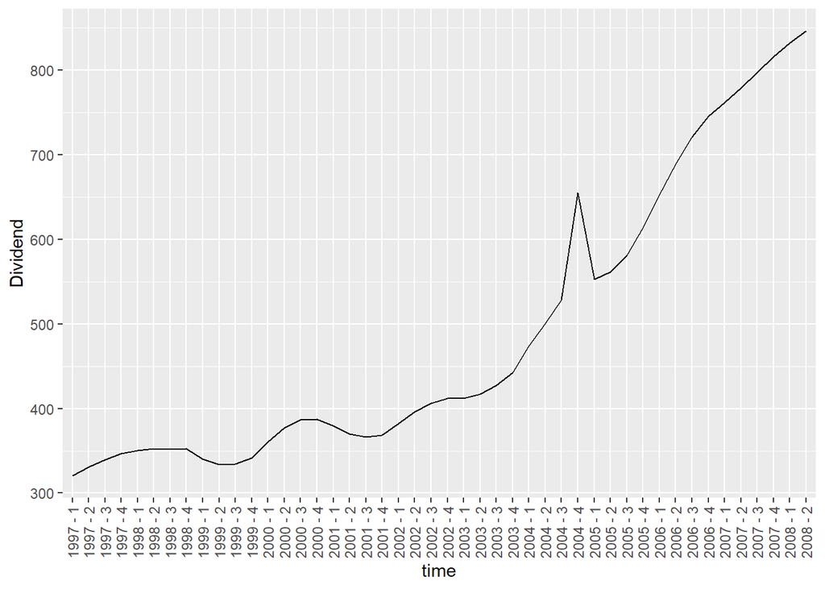

```r
df_corpfin$time <- paste(df_corpfin$Year,paste("-",df_corpfin$Quarter))

ggplot(data = df_corpfin) +
  geom_line(mapping = aes(x= time, y = Dividend, group = 1))+
  theme(axis.text.x = element_text(angle = 90, vjust = 0.5, hjust=1))
```

```r
cat("The interaction terms would capture the differences in slopes and intercepts from quarter to quarter. The above model is significant.(Global p-value less than the significance). And individual dividends and quarters also signifies the same thing with individual p-value not being significant")
```

```
## The interaction terms would capture the differences in slopes and intercepts from quarter to quarter. The above model is significant.(Global p-value less than the significance). And individual dividends and quarters also signifies the same thing with individual p-value not being significant
```

[output not shown]

# Question-7

```r
df_lawn <- read.csv("Mowers.csv")
head(df_lawn,2)
```

```
##   Sales Temperature Advertising Discount
## 1 17235          33          15        5
## 2 19854          42          25        5
```

$y_{sales} = \beta_{0} + \beta_{1}*temperature + \beta_{2}*advertising + \beta_{3}*discount + \epsilon$

```r
model_lawn <- lm(Sales~Temperature + Advertising + Discount, data = df_lawn)
summary(model_lawn)
```

```
##
## Call:
## lm(formula = Sales ~ Temperature + Advertising + Discount, data = df_lawn)
##
## Residuals:
##     Min      1Q  Median      3Q     Max
## -8843.7 -3074.2   807.8  2337.2  7697.1
##
## Coefficients:
##             Estimate Std. Error t value Pr(>|t|)
## (Intercept)  -1730.1     5791.3  -0.299   0.7682
## Temperature    303.0      176.1   1.721   0.1008
## Advertising    505.6      179.6   2.814   0.0107 *
## Discount       202.2      320.2   0.632   0.5348
## ---
## Signif. codes:  0 '***' 0.001 '**' 0.01 '*' 0.05 '.' 0.1 ' ' 1
##
## Residual standard error: 4533 on 20 degrees of freedom
## Multiple R-squared:  0.9431, Adjusted R-squared:  0.9345
## F-statistic: 110.5 on 3 and 20 DF,  p-value: 1.285e-12
```

**Joint Hypothesis:**  
$H_{o}$ : $\beta_{temperature}$ $=$ $\beta_{advertising}$ $=$ $\beta_{discount}$ $=$ 0  
$H_{1}$ : At least one beta(i) is not equal to zero.

**Temperature Hypothesis:**  
$H_{o}$ : $\beta_{temperature}$ $=$ 0  
$H_{1}$ : $\beta_{temperature}$ $\neq$ 0

**Advertising Hypothesis:**  
$H_{o}$ : $\beta_{Advertising}$ $=$ 0  
$H_{1}$ : $\beta_{Advertising}$ $\neq$ 0

**Discount Hypothesis:**  
$H_{o}$ : $\beta_{Discount}$ $=$ 0  
$H_{1}$ : $\beta_{Discount}$ $\neq$ 0

[output not shown]

```r
cor(df_lawn)
```

```
##                 Sales Temperature Advertising  Discount
## Sales       1.0000000   0.9216025   0.9664488 0.7838697
## Temperature 0.9216025   1.0000000   0.9168112 0.6244100
## Advertising 0.9664488   0.9168112   1.0000000 0.8258107
## Discount    0.7838697   0.6244100   0.8258107 1.0000000
```

```
## As we can see there is strong positive correlation between the Advertising and Temperature, Advertising and Discount
```

```r
car::vif(model_lawn)
```

```
## Temperature Advertising    Discount
##    9.607405   18.430557    4.816958
```

```r
1/(1-0.9345)
```

```
## [1] 15.26718
```

```
## As the advertising vif value is greater than 10 and greater than 1/(1-R2) value, suggests multicollinearity exists between the variables.
```

[output not shown]